# Lab3

Megan Rowland

4/1/2022

```r
knitr::opts_chunk$set(echo = TRUE)
```

```
## here() starts at /Users/meganrowland/Documents/CPP528/CPP-528-Project
```

```
## The import package should not be attached.
## Use "colon syntax" instead, e.g. import::from, or import:::from.
```

```
##  Hlavac, Marek (2022). stargazer: Well-Formatted Regression and Summary Statistics Tables.
```

```
##  R package version 5.2.3. https://CRAN.R-project.org/package=stargazer
```

```
## Package 'mclust' version 5.4.7
```

```
## Checking rgeos availability: TRUE
```

```r
# note: please do not use static file paths
# note: notice down below the use of here::here()
d1 <- readRDS( here::here( "data/rodeo/LTDB-1990.rds" ) )
d2 <- readRDS( here::here( "data/rodeo/LTDB-2000.rds" ) )
md <- readRDS( here::here( "data/rodeo/LTDB-META-DATA.rds" ) )

# check to make sure we are not losing
# or gaining observations in the merge
nrow( d1 )
```

```
## [1] 72693
```

```r
d1 <- select( d1, - year )
d2 <- select( d2, - year )

d <- merge( d1, d2, by="tractid" )
d <- merge( d, md, by="tractid" )

nrow( d )
```

```
## [1] 72693
```

```r
table( d$urban )
```

```
##
## rural urban
## 12971 59722
```

```r
d <- filter( d, urban == "urban" )
```

Identify Common Variables

```r
vars <- compare_dfs( df1=d1, df2=d2 )
```

```
## [1] "SHARED VARIABLES:"
##   [1] "a15asn"  "a15blk"  "a15hsp"  "a15ntv"  "a15wht"  "a18und"  "a60asn"
##   [8] "a60blk"  "a60hsp"  "a60ntv"  "a60up"   "a60wht"  "a75up"   "ag15up"
##  [15] "ag25up"  "ag5up"   "ageasn"  "ageblk"  "agehsp"  "agentv"  "agewht"
##  [22] "asian"   "china"   "clf"     "cni16u"  "col"     "cuban"   "dapov"
##  [29] "dbpov"   "dflabf"  "dfmpov"  "dhpov"   "dis"     "dmulti"  "dnapov"
##  [36] "dpov"    "dwpov"   "empclf"  "family"  "fb"      "fhh"     "filip"
##  [43] "flabf"   "geanc"   "gefb"    "h10yrs"  "h30old"  "haw"     "hh"
##  [50] "hha"     "hhb"     "hhh"     "hhw"     "hinc"    "hinca"   "hincb"
##  [57] "hinch"   "hincw"   "hisp"    "hs"      "hu"      "incpc"   "india"
##  [64] "iranc"   "irfb"    "itanc"   "itfb"    "japan"   "korea"   "lep"
##  [71] "manuf"   "mar"     "mex"     "mhmval"  "mrent"   "multi"   "n10imm"
##  [78] "n65pov"  "napov"   "nat"     "nbpov"   "nfmpov"  "nhblk"   "nhpov"
##  [85] "nhwht"   "nnapov"  "npov"    "ntv"     "nwpov"   "ohu"     "olang"
##  [92] "own"     "pop"     "pr"      "prof"    "rent"    "ruanc"   "rufb"
##  [99] "scanc"   "scfb"    "semp"    "tractid" "unemp"   "vac"     "vet"
## [106] "viet"    "wds"
## [1] "NOT SHARED:"
## [1] "ag16cv"  "ag18cv"  "hu00sp"  "hu90sp"  "ohu00sp" "ohu90sp" "pop90.1"
```

```r
head( vars )
```

```
##     type variables
## 1 shared    a15asn
## 2 shared    a15blk
## 3 shared    a15hsp
## 4 shared    a15ntv
## 5 shared    a15wht
## 6 shared    a18und
```

Create Dataset for Analysis

```r
d.full <- d  # keep a copy so don't have to reload

d <- d.full  # store original in case you need to reset anything

d <- select( d, tractid, mhmval00, mhmval90, hinc90,
             hu90, own90, rent90,
             empclf90, clf90, unemp90, prof90,
             dpov90, npov90,
             ag25up90, hs90, col90,
             pop90.x, nhwht90, nhblk90, hisp90, asian90,
             cbsa, cbsaname )
d <-
  d %>%
  mutate( p.white = 100 * nhwht90 / pop90.x,
          p.black = 100 * nhblk90 / pop90.x,
          p.hisp = 100 * hisp90 / pop90.x,
          p.asian = 100 * asian90 / pop90.x,
          p.hs = 100 * (hs90+col90) / ag25up90,
          p.col = 100 * col90 / ag25up90,
          p.prof = 100 * prof90 / empclf90,
          p.unemp = 100 * unemp90 / clf90,
          pov.rate = 100 * npov90 / dpov90 )
```

```r
stargazer( d,
           type= "text",
           digits=0,
           summary.stat = c("min", "p25","median","mean","p75","max") )
```

```
##
## ===========================================================
## Statistic  Min  Pctl(25) Median   Mean   Pctl(75)    Max
## -----------------------------------------------------------
## mhmval00    0    81,600  119,900 144,738 173,894  1,000,001
## mhmval90    0    58,800  86,500  112,399 141,800   500,001
## hinc90    4,999  24,355  32,033  34,160   41,520   150,001
## hu90        0     916     1,337   1,382   1,804    11,003
## own90       0     422      744     788    1,093     8,180
## rent90      0     168      358     476     663      8,653
## empclf90    0    1,015    1,555   1,625   2,157    11,816
## clf90       0    1,101    1,664   1,732   2,291    12,497
## unemp90     0      49      88      107     143      1,165
## prof90      0     192      359     451     616      6,290
## dpov90      0    2,219    3,250   3,332   4,365    23,619
## npov90      0     112      248     406     526      5,890
## ag25up90    0    1,444    2,121   2,187   2,865    18,461
## hs90        0     626     1,064   1,141   1,559    12,383
## col90       0     162      335     483     652      8,575
## pop90.x     0    2,283    3,325   3,419   4,464    35,721
## nhwht90     0    1,262    2,424   2,513   3,575    21,561
## nhblk90     0      18      76      426     331     12,121
## hisp90      0      27      75      347     280     13,873
## asian90     0      9       31      111      94      7,899
## p.white     0      64      87      74       95       100
## p.black     0      1        3      12       10       100
## p.hisp      0      1        3      10       9        100
## p.asian     0      0        1       3       3        94
## p.hs        0      69      74      74       80       100
## p.col       0      10      18      22       30       100
## p.prof      0      17      25      27       34       100
## p.unemp     0      4        5       7       8        64
## pov.rate    0      4        8      12       16       100
## -----------------------------------------------------------
```

Exploration of Median Home Value

```r
# adjust 2000 home values for inflation
mhv.90 <- d$mhmval90 * 1.31
mhv.00 <- d$mhmval00

mhv.change <- mhv.00 - mhv.90

df <- data.frame( MedianHomeValue1990=mhv.90,
                  MedianHomeValue2000=mhv.00,
                  Change.90.to.00=mhv.change )

stargazer( df,
           type= "text",
           digits=0,
           summary.stat = c("min", "p25","median","mean","p75","max") )
```

```
##
## ========================================================================
## Statistic             Min    Pctl(25) Median   Mean   Pctl(75)    Max
## ------------------------------------------------------------------------
## MedianHomeValue1990    0      77,028  113,315 147,243 185,758   655,001
## MedianHomeValue2000    0      81,600  119,900 144,738 173,894  1,000,001
## Change.90.to.00     -655,001 -22,087   1,151  -2,505   19,876  1,000,001
## ------------------------------------------------------------------------
```

Inflation https://westegg.com/inflation/

```r
# 10 year inflation factor
(1.031)^10
```

```
## [1] 1.357021
```

Histogram of MHV

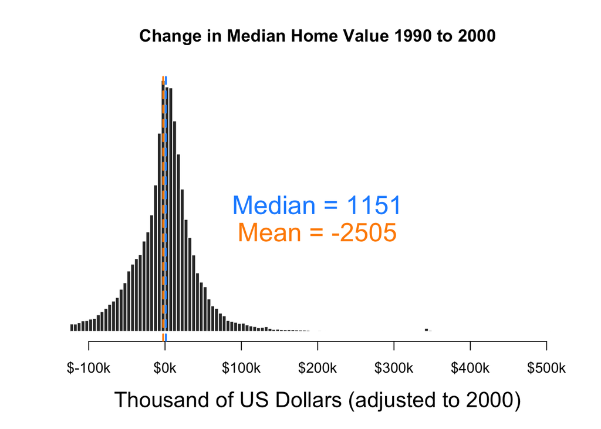

```r
hist( mhv.change/1000, breaks=500,
      xlim=c(-100,500), yaxt="n", xaxt="n",
      xlab="Thousand of US Dollars (adjusted to 2000)", cex.lab=1.5,
      ylab="", main="Change in Median Home Value 1990 to 2000",
      col="gray20", border="white" )

axis( side=1, at=seq( from=-100, to=500, by=100 ),
      labels=paste0( "$", seq( from=-100, to=500, by=100 ), "k" ) )

mean.x <- mean( mhv.change/1000, na.rm=T )
abline( v=mean.x, col="darkorange", lwd=2, lty=2 )
text( x=200, y=1500,
      labels=paste0( "Mean = ",  round(1000*mean.x,0)) ,
      col="darkorange", cex=1.8, pos=3 )

median.x <- median( mhv.change/1000, na.rm=T )
abline( v=median.x, col="dodgerblue", lwd=2, lty=2 )
text( x=200, y=2000,
      labels=paste0( "Median = ",  round(1000*median.x,0)) ,
      col="dodgerblue", cex=1.8, pos=3 )
```

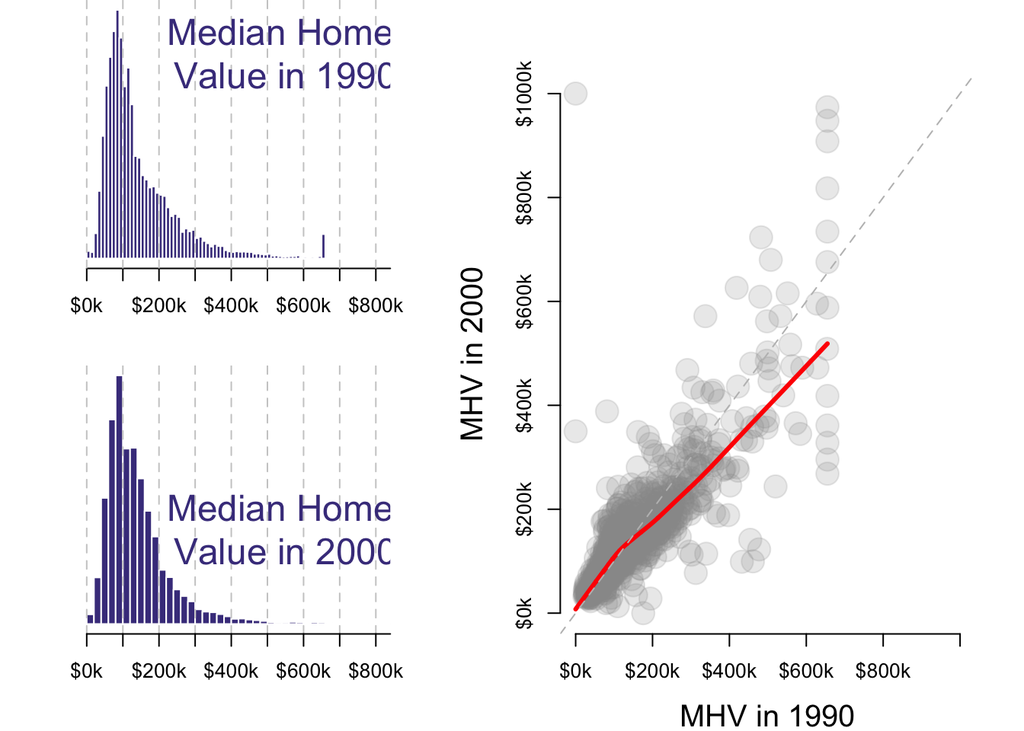

```r
# function to control plot() formatting

layout.matrix <- matrix( c( 1,3,
                            2,3 ),
                nrow=2, ncol=2, byrow=T )

layout( mat = layout.matrix,
        heights = c(2,2), # Heights of the two rows
        widths =  c(3,4)) # Widths of the two columns

# layout.show(3)

par( mar=c(4,0,0,2) )

hist( mhv.90/1000, breaks=50,
      xlim=c(-200,800), yaxt="n", xaxt="n",
      xlab="", cex.lab=1,
      ylab="", main="",
      col="darkslateblue", border="white" )

axis( side=1, at=seq( from=0, to=1000, by=100 ),
      labels=paste0( "$", seq( from=0, to=1000, by=100 ), "k" ) )

abline( v=seq(0,1000,100), lty=2, col="gray80" )

text( 550, 4000, labels="Median Home \nValue in 1990",
      col="darkslateblue", cex=1.8 )



hist( mhv.00/1000, breaks=50,
      xlim=c(-200,800), yaxt="n", xaxt="n",
      xlab="", cex.lab=1,
      ylab="", main="",
      col="darkslateblue", border="white" )

abline( v=seq(0,1000, 100 ), lty=2, col="gray80" )

text( 550, 3500, labels="Median Home \nValue in 2000",
      col="darkslateblue", cex=1.8 )

axis( side=1, at=seq( from=0, to=1000, by=100 ),
      labels=paste0( "$", seq( from=0, to=1000, by=100 ), "k" ) )


# data reduction - filter 1,000 observations

df <- data.frame( v90=mhv.90/1000, v00=mhv.00/1000 )
df <- sample_n( df, 1000 )

par( mar=c(4,5,3,2) )

jplot( df$v90, df$v00,
       lab1="MHV in 1990", lab2="MHV in 2000",
       xlim=c(0,1000), ylim=c(0,1000),
       axes=F )

abline( a=0, b=1, lty=2, col="gray" )
axis( side=1, at=seq( from=0, to=1000, by=200 ),
      labels=paste0( "$", seq( from=0, to=1000, by=200 ), "k" ) )
axis( side=2, at=seq( from=0, to=1000, by=200 ),
      labels=paste0( "$", seq( from=0, to=1000, by=200 ), "k" ) )
```

Change in MHV 1990-2000

```r
# small initial values are skewing percentages
#
# an average home value below $10k is really low -
# these must be mostly vacant lots?

# interpretation is hard if there were no homes in 2000
# and thus an artificially low MHV. i don't trust cases
# that go from homes worth $10k to regular value
# because it is more likely errors in data or noise
# than meaningful variance
#
# quick filter to remove all of the problematic obs
# but need to go back and see which cases are problematic


mhv.90[ mhv.90 < 10000 ] <- NA
pct.change <- mhv.change / mhv.90
summary( pct.change )
```

```
##     Min.  1st Qu.   Median     Mean  3rd Qu.     Max.     NA's
## -1.00000 -0.15300  0.01203  0.05821  0.21139 28.54641      145
```

```r
# how many cases had increases above 500%
sum( pct.change > 5, na.rm=T )
```

```
## [1] 26
```

```r
# preview tracts with large increases in home values
# to see if increases make sense

d %>%
  filter( pct.change > 5 ) %>%
  head()
```

```
##              tractid  mhmval00 mhmval90    hinc90      hu90     own90   rent90
## 1 fips-01-097-000402  593426.5 67488.60  4999.014  673.0189 15.003853 651.0111
## 2 fips-04-019-000100  625000.0 73035.87  5059.955  457.5807 22.886298 382.3900
## 3 fips-12-099-002600  625000.0 63800.00 15820.000  242.0000 20.000000 188.0000
## 4 fips-13-121-002100  261100.0 32500.00  4999.000 1080.0000  8.000000 999.0000
## 5 fips-17-031-842200  281775.9 21601.50  6861.296 1239.2981  9.245283 738.5132
## 6 fips-17-167-001400 1000001.0 55000.00  8927.000  678.0000  4.000000 590.0000
##   empclf90    clf90   unemp90    prof90    dpov90   npov90  ag25up90      hs90
## 1 293.0073 535.0116 242.00434  14.00054 2139.0431 1857.030  812.0255  665.0209
## 2 162.6119 181.9220  19.31012  40.20623  581.4132  358.757  498.2508  312.9027
## 3 448.0000 448.0000   0.00000  62.00000  575.0000  120.000  527.0000  421.0000
## 4 550.0000 732.0000 182.00000  27.00000 2663.0000 1862.000 1426.0000 1164.0000
## 5 261.5132 502.2981 240.78491  41.12830 2430.3019 1945.589 1065.5434  953.4642
## 6 294.0000 328.0000  34.00000 126.00000  692.0000  247.000  710.0000  408.0000
##        col90  pop90.x    nhwht90    nhblk90     hisp90   asian90  cbsa
```

[output cut: 20 more lines]

Plot % Change

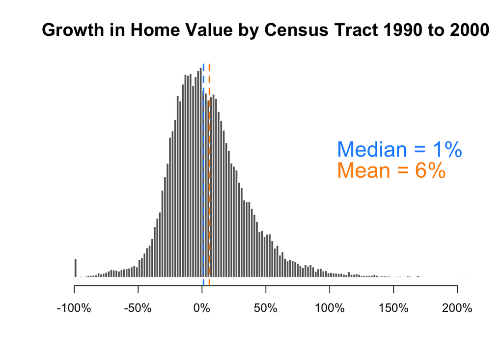

```r
hg <-
hist( pct.change, breaks=2000,
      xlim=c(-1,2), yaxt="n", xaxt="n",
      xlab="", cex.main=1.5,
      ylab="", main="Growth in Home Value by Census Tract 1990 to 2000",
      col="gray40", border="white" )

axis( side=1, at=seq( from=-1, to=2, by=0.5 ),
      labels=paste0( seq( from=-100, to=200, by=50 ), "%" ) )

ymax <- max( hg$count )

mean.x <- mean( pct.change, na.rm=T )
abline( v=mean.x, col="darkorange", lwd=2, lty=2 )
text( x=1, y=(0.5*ymax),
      labels=paste0( "Mean = ", round(100*mean.x,0), "%"),
      col="darkorange", cex=1.8, pos=4 )

median.x <- median( pct.change, na.rm=T )
abline( v=median.x, col="dodgerblue", lwd=2, lty=2 )
text( x=1, y=(0.6*ymax),
      labels=paste0( "Median = ", round(100*median.x,0), "%"),
      col="dodgerblue", cex=1.8, pos=4 )
```

Group Growth Rates by Metro Area

```r
d$mhv.change <- mhv.change
d$pct.change <- pct.change
d$mhv.90 <- mhv.90
d$mhv.00 <- mhv.00

d %>%
  group_by( cbsaname ) %>%
  summarize( ave.change = median( mhv.change, na.rm=T ),
             ave.change.d = dollar( round(ave.change,0) ),
             growth = 100 * median( pct.change, na.rm=T ) ) %>%
  ungroup() %>%
  arrange( - growth ) %>%
  select( - ave.change ) %>%
  head( 25 ) %>%
  pander()
```

[output not shown]

Measuring Gentrification

```r
# adjust 2000 home values for inflation
mhv.90 <- d.full$mhmval90 * 1.31
mhv.00 <- d.full$mhmval00

mhv.change <- mhv.00 - mhv.90

# small initial values are skewing percentages
#
# an average home value below $10k is really low -
# these must be mostly vacant lots?

mhv.90[ mhv.90 < 10000 ] <- NA
pct.change <- 100 * ( mhv.change / mhv.90 )
summary( pct.change )
```

```
##     Min.  1st Qu.   Median     Mean  3rd Qu.     Max.     NA's
## -100.000  -15.300    1.203    5.821   21.139 2854.641      145
```

```r
d.full$mhv.90 <- mhv.90
d.full$mhv.00 <- mhv.00
d.full$mhv.change <- mhv.change
d.full$pct.change <- pct.change
```

Select Gentrification Variables

```r
d3 <- select( d.full,

             tractid, cbsa, cbsaname,            # ids / units of analysis

             mhv.90, mhv.00, mhv.change, pct.change,    # home value

             hinc00, hu00, own00, rent00,        # ses
             hinc90, hu90, own90, rent90,

             empclf00, clf00, unemp00, prof00,   # employment
             empclf90, clf90, unemp90, prof90,

             dpov00, npov00, nfmpov00, dfmpov00, dapov00, dwpov00,    # poverty and race
             dpov90, npov90, nfmpov90, dfmpov90, dapov90, dwpov90,

             ag25up00, hs00, col00,              # education
             ag25up90, hs90, col90,

             pop00.x, nhwht00, nhblk00, hisp00, asian00,   # race
             pop90.x, nhwht90, nhblk90, hisp90, asian90

          ) # end select


d3 <-
  d3 %>%
  mutate(
          # 2000 variables
          p.white.00 = 100 * nhwht00 / pop00.x,
          p.black.00 = 100 * nhblk00 / pop00.x,
          p.hisp.00 = 100 * hisp00 / pop00.x,
          p.asian.00 = 100 * asian00 / pop00.x,
          p.hs.edu.00 = 100 * (hs00+col00) / ag25up00,
          p.col.edu.00 = 100 * col00 / ag25up00,
          p.prof.00 = 100 * prof00 / empclf00,
          p.unemp.00 = 100 * unemp00 / clf00,
          pov.rate.00 = 100 * npov00 / dpov00,

          # 1990 variables
          p.white.90 = 100 * nhwht90 / pop90.x,
          p.black.90 = 100 * nhblk90 / pop90.x,
          p.hisp.90 = 100 * hisp90 / pop90.x,
          p.asian.90 = 100 * asian90 / pop90.x,
          p.hs.edu.90 = 100 * (hs90+col90) / ag25up90,
          p.col.edu.90 = 100 * col90 / ag25up90,
          p.prof.90 = 100 * prof90 / empclf90,
          p.unemp.90 = 100 * unemp90 / clf90,
          pov.rate.90 = 100 * npov90 / dpov90 )
```

```r
d3 <-
  d3 %>%
  group_by( cbsaname ) %>%
  mutate( metro.mhv.pct.00 = ntile( mhv.00, 100 ),
          metro.mhv.pct.90 = ntile( mhv.90, 100 ),
          metro.median.pay.00 = median( hinc00, na.rm=T ),
          metro.median.pay.90 = median( hinc90, na.rm=T ),
          metro.race.rank.90 = ntile( (100-p.white.90), 100),
          coleducation.00 = ntile(p.col.edu.00, 100),
          coleducation.90 = ntile(p.col.edu.90, 100),
          unemploy.00 = ntile(p.unemp.00, 100) ,
          unemploy.90 = ntile(p.unemp.90, 100 ),
          fam.pov.pct.90 = 100 * nfmpov90 / dfmpov90,
          p.rent.housing90 = 100 * rent90 / hu90,
          p.rent.housing00 = 100 * rent00 / hu00,
          fam.pov.pct.00 = 100 * nfmpov00 / dfmpov00,
          metro.asian.rank.90 = ntile( (100-p.asian.90), 100 ))  %>%
  ungroup() %>%
  mutate( metro.mhv.pct.change = metro.mhv.pct.00 - metro.mhv.pct.90,
          upward.pay.change = metro.median.pay.00 - metro.median.pay.90,
          race.change = p.white.00 - p.white.90,
          mhv.change = mhv.00 - mhv.90,
          collegeedu.change = coleducation.00 - coleducation.90,
          unemploy.change = unemploy.00 - unemploy.90,
          p.rent.housing.change = p.rent.housing00 - p.rent.housing90,
          fam.pov.pct.change = fam.pov.pct.00 - fam.pov.pct.90,
          asian.race.change = p.asian.00 - p.asian.90
)
```

Descriptive Statistics of Change Variables

```r
d3 <-
  d3 %>%
  select( c( "tractid", "cbsa", "cbsaname",
             "mhv.00", "mhv.90", "mhv.change","pct.change",
          "p.white.00", "p.black.00", "p.hisp.00", "p.asian.00",
          "p.hs.edu.00", "p.col.edu.00", "p.prof.00",  "p.unemp.00",
          "pov.rate.00", "p.white.90", "p.black.90", "p.hisp.90",
          "p.asian.90", "p.hs.edu.90", "p.col.edu.90", "p.prof.90",
          "p.unemp.90", "pov.rate.90", "metro.mhv.pct.00",
          "metro.mhv.pct.90", "metro.median.pay.00", "metro.median.pay.90",
          "metro.mhv.pct.change", "upward.pay.change", "race.change",
          "metro.race.rank.90", "coleducation.00","coleducation.90", "unemploy.00", "unemploy.90", "collegeedu.change", "unemploy.change",
          "fam.pov.pct.90", "fam.pov.pct.00", "p.rent.housing90", "p.rent.housing00", "p.rent.housing.change", "fam.pov.pct.change",
          "dpov00", "npov00", "nfmpov00", "dfmpov00", "dapov00", "dwpov00",    # poverty and race
             "dpov90", "npov90", "nfmpov90", "dfmpov90", "dapov90", "dwpov90", "metro.asian.rank.90", "asian.race.change") )

# head( d3 ) %>% pander()
```

```r
d3 <- data.frame(d3)
stargazer( d3,
           type= "text",
           digits=0,
           summary.stat = c("min", "p25","median","mean","p75","max") )
```

```
##
## ==========================================================================
## Statistic               Min    Pctl(25) Median   Mean   Pctl(75)    Max
## --------------------------------------------------------------------------
## mhv.00                   0      81,600  119,900 144,738 173,894  1,000,001
## mhv.90                 11,623   77,290  113,446 147,601 186,020   655,001
## mhv.change            -655,001 -22,178   1,100  -2,995   19,777   963,976
## pct.change              -100     -15       1       6       21      2,855
## p.white.00               0        47      78      67       91       100
## p.black.00               0        1        4      14       14       100
## p.hisp.00                0        2        4      13       15       100
## p.asian.00               0        1        2       5       5        95
## p.hs.edu.00              0        67      72      72       77       100
## p.col.edu.00             0        12      21      26       36       100
## p.prof.00                0        23      31      34       43       100
## p.unemp.00               0        3        5       6       8        100
## pov.rate.00              0        4        9      12       17       100
## p.white.90               0        64      87      74       95       100
## p.black.90               0        1        3      12       10       100
## p.hisp.90                0        1        3      10       9        100
## p.asian.90               0        0        1       3       3        94
## p.hs.edu.90              0        69      74      74       80       100
## p.col.edu.90             0        10      18      22       30       100
## p.prof.90                0        17      25      27       34       100
## p.unemp.90               0        4        5       7       8        64
## pov.rate.90              0        4        8      12       16       100
## metro.mhv.pct.00         1        20      41      45       68       100
## metro.mhv.pct.90         1        20      41      45       68       100
## metro.median.pay.00    23,012   39,457  43,139  45,054   49,522   73,701
## metro.median.pay.90    14,871   28,906  32,457  32,924   35,833   52,374
## metro.mhv.pct.change    -99       -5       0       0       6        99
## upward.pay.change      4,930    9,775   11,441  12,130   14,001   26,211
## race.change             -100     -12      -5      -8       -2       100
## metro.race.rank.90       1        20      41      45       68       100
## coleducation.00          1        20      41      45       68       100
## coleducation.90          1        20      41      45       68       100
## unemploy.00              1        20      41      45       68       100
## unemploy.90              1        20      41      45       68       100
## collegeedu.change       -99       -6       0       0       5        99
## unemploy.change         -99      -13       0      -0       12       99
## fam.pov.pct.90           0        45      52      52       59       100
## fam.pov.pct.00           0        2        4       8       10       100
## p.rent.housing90         0        16      28      33       46       100
## p.rent.housing00         0        15      27      32       46       100
## p.rent.housing.change   -100      -3      -0      -0       2        100
## fam.pov.pct.change      -100     -51      -45     -44     -38       62
## dpov00                   0      2,671    3,718   3,804   4,871    23,892
## npov00                   0       149      304     452     601      5,515
## nfmpov00                 0        16      40      68       91       949
## dfmpov00                 0       678      964     991    1,283     6,399
## dapov00                  0        12      53      167     162      9,318
## dwpov00                  0      1,251    2,457   2,530   3,643    13,422
## dpov90                   0      2,219    3,250   3,332   4,365    23,619
## npov90                   0       112      248     406     526      5,890
## nfmpov90                 0       280      437     458     611      4,059
## dfmpov90                 0       574      860     887    1,169     6,863
## dapov90                  0        6       30      113     100      7,905
## dwpov90                  0      1,451    2,549   2,630   3,659    16,420
## metro.asian.rank.90      1        20      41      45       68       100
## asian.race.change       -32       0        1       2       2        92
## --------------------------------------------------------------------------
```

Operationalizing Gentrification

```r
# income
# percent white
# home values absolute
# home value relative to metro
# education stats ?
# employment stats ?
# income stats ?
# growth of pop per tract (density) ?
d3 <-
  d3 %>%
  mutate(
# low income (take from median and mean metro pay 1990)
    low.median.pay1990 = d3$metro.median.pay.90 < 35000,

# above average population asian (taken from dapov90)
    pov.asian.pop.high1990 = d3$dapov90 > 112,

# low median house value (taken from median MHV for 1990)
    low.mhv.90 =mhv.90 < 114000,

#Gentrification-post markers:

# pay change from 2000 - 1990 (inverse variable, by median)
    increase.in.pay = d3$upward.pay.change > 12000,

# household income increase
    #increase.household.income <- d3$hh.inc.rank.pct.change > 10 ,

# decrease in families with children in poverty
    fam.pov.pct.decrease = d3$fam.pov.pct.change < 1,

# decrease in percentage renters of housing units
    pct.rent.housing.decrease = d3$p.rent.housing.change > 0,

    g.flag = increase.in.pay & fam.pov.pct.decrease & pct.rent.housing.decrease )
```

```r
d3 <-
  d3 %>%
  select( c( "tractid", "cbsa", "cbsaname",
             "mhv.00", "mhv.90", "mhv.change","pct.change",
          "p.white.00", "p.black.00", "p.hisp.00", "p.asian.00",
          "p.hs.edu.00", "p.col.edu.00", "p.prof.00",  "p.unemp.00",
          "pov.rate.00", "p.white.90", "p.black.90", "p.hisp.90",
          "p.asian.90", "p.hs.edu.90", "p.col.edu.90", "p.prof.90",
          "p.unemp.90", "pov.rate.90", "metro.mhv.pct.00",
          "metro.mhv.pct.90", "metro.median.pay.00", "metro.median.pay.90",
          "metro.mhv.pct.change", "upward.pay.change", "race.change",
          "metro.race.rank.90", "coleducation.00","coleducation.90", "unemploy.00", "unemploy.90",
          "collegeedu.change", "unemploy.change","fam.pov.pct.90", "fam.pov.pct.00",
          "p.rent.housing90", "p.rent.housing00", "p.rent.housing.change",
          "fam.pov.pct.change","low.median.pay1990", "pov.asian.pop.high1990", "low.mhv.90",
          "increase.in.pay", "fam.pov.pct.decrease", "pct.rent.housing.decrease", "g.flag", "fam.pov.pct.90", "fam.pov.pct.00", "p.rent.housing90", "p.rent.housing00", "p.rent.housing.change", "fam.pov.pct.change",
          "dpov00", "npov00", "nfmpov00", "dfmpov00", "dapov00", "dwpov00",    # poverty and race
             "dpov90", "npov90", "nfmpov90", "dfmpov90", "dapov90", "dwpov90", "metro.asian.rank.90", "asian.race.change") )

num.candidates <-  sum( d3$low.median.pay1990 & d3$pov.asian.pop.high1990 & d3$low.mhv.90 & d3$pct.rent.housing.decrease, na.rm = T )
num.gentrified <- sum( d3$g.flag, na.rm=T )

num.gentrified
```

```
## [1] 11538
```

```r
num.candidates
```

```
## [1] 972
```

```r
(num.gentrified / num.candidates)
```

```
## [1] 11.87037
```

```r
num.candidates / num.gentrified
```

```
## [1] 0.08424337
```

```r
# small initial values are skewing percentages
#
# an average home value below $10k is really low -
# these must be mostly vacant lots?

mhv.90[ mhv.90 < 1000 ] <- NA
pct.change <- 100 * ( mhv.change / mhv.90 )
summary( pct.change )
```

```
##     Min.  1st Qu.   Median     Mean  3rd Qu.     Max.     NA's
## -100.000  -15.300    1.203    5.821   21.139 2854.641      145
```

Part 3 Cartograms

```r
key <- "ecaca1861b59210661b330db28f205f5845e226a"
census_api_key( key )
```

```
## To install your API key for use in future sessions, run this function with `install = TRUE`.
```

```r
crosswalk <- read.csv( "https://raw.githubusercontent.com/DS4PS/cpp-529-master/master/data/cbsatocountycrosswalk.csv",  stringsAsFactors=F, colClasses="character" )
# search for citie names by strings, use the ^ anchor for "begins with"
grep( "^al", crosswalk$msaname, value=TRUE )
```

```
## character(0)
```

```r
these.msp <- crosswalk$msaname == "SAN DIEGO, CA"
these.fips <- crosswalk$fipscounty[ these.msp ]
these.fips <- na.omit( these.fips )
state.fips <- substr( these.fips, 1, 2 )
county.fips <- substr( these.fips, 3, 5 )
san.pop <-
get_acs( geography = "tract", variables = "B01003_001",
         state = "06", county = county.fips[state.fips=="06"], geometry = TRUE ) %>%
         select( GEOID, estimate ) %>%
         rename( POP=estimate )
these.san <- d3 %>%
  filter(d3$cbsaname =="San Diego-Carlsbad-San Marcos, CA")

these.san$tractid <- gsub("-", "", these.san$tractid)
these.san$tractid <- substring(these.san$tractid, 5)


san <- merge(san.pop, these.san, by.x="GEOID", by.y="tractid")
san <- san[ ! st_is_empty( san ) , ]

# convert sf map object to an sp version
san.sp <- as_Spatial( san )

class( san.sp )
```

```
## [1] "SpatialPolygonsDataFrame"
## attr(,"package")
## [1] "sp"
```

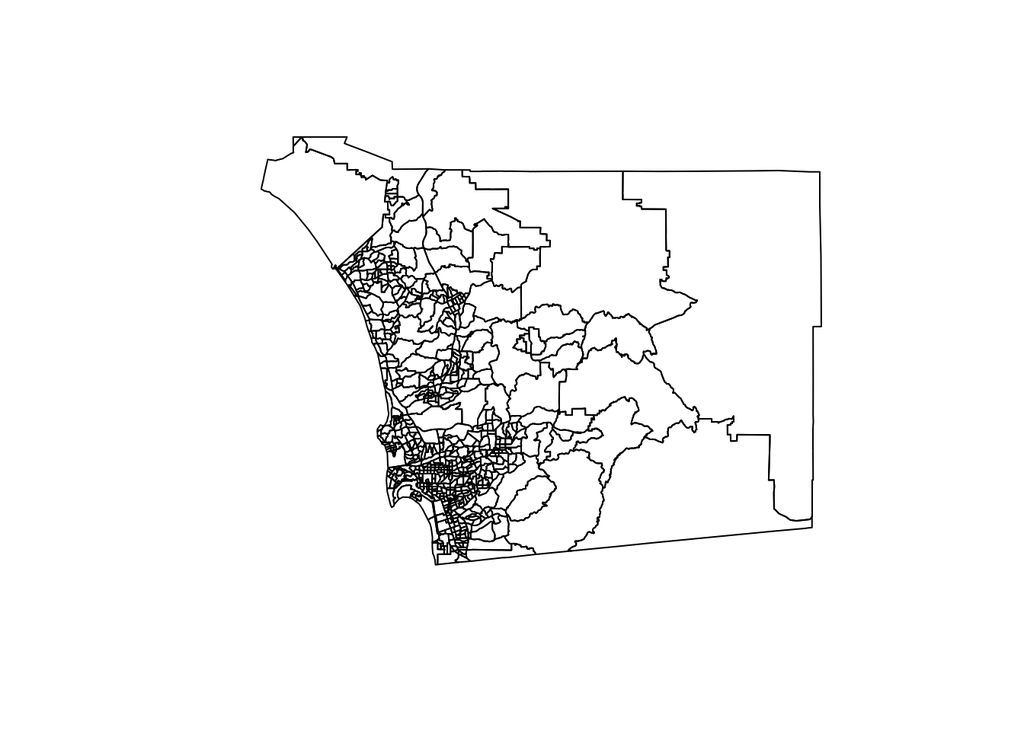

```r
plot( san.sp )
```

Dorling

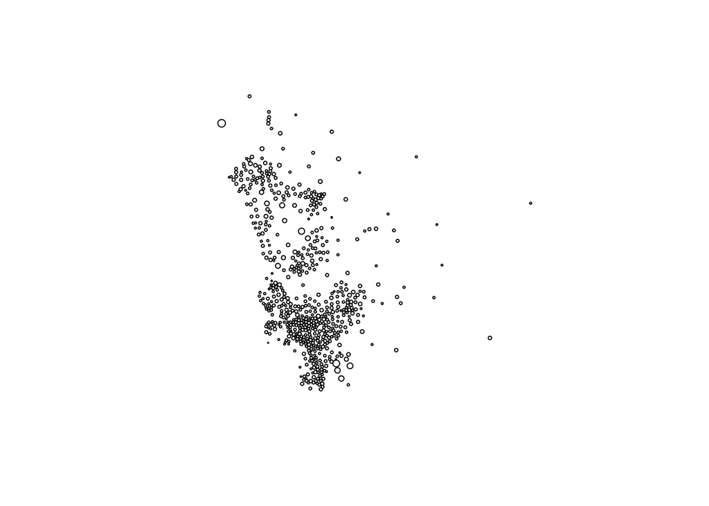

```r
# project map and remove empty tracts
san.sp <- spTransform( san.sp, CRS("+init=epsg:3395"))
san.sp <- san.sp[ san.sp$POP != 0 & (! is.na( san.sp$POP )) , ]

# convert census tract polygons to dorling cartogram
# no idea why k=0.03 works, but it does - default is k=5
san.sp$pop.w <- san.sp$POP / 9000 # max(msp.sp$POP)   # standardizes it to max of 1.5
san_dorling <- cartogram_dorling( x=san.sp, weight="pop.w", k=0.05 )
plot( san_dorling )
```

Home Value 1990

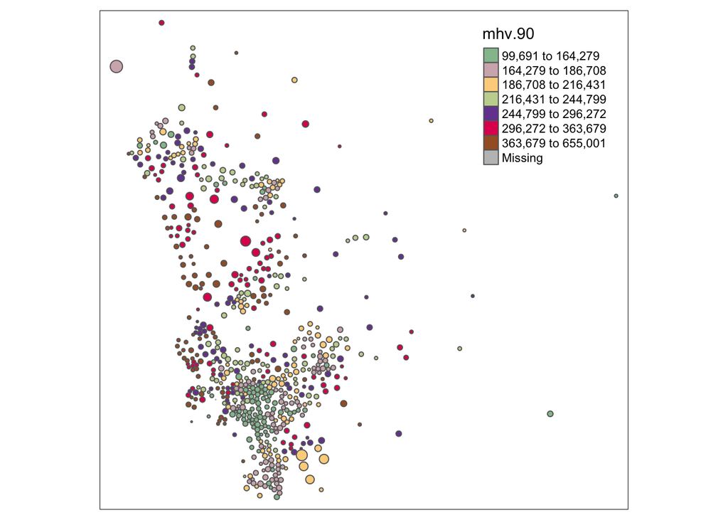

```r
tm_shape( san_dorling ) +
  tm_polygons( size="POP", col="mhv.90", n=7, style="quantile", palette="Accent" )
```

Home Value 2000

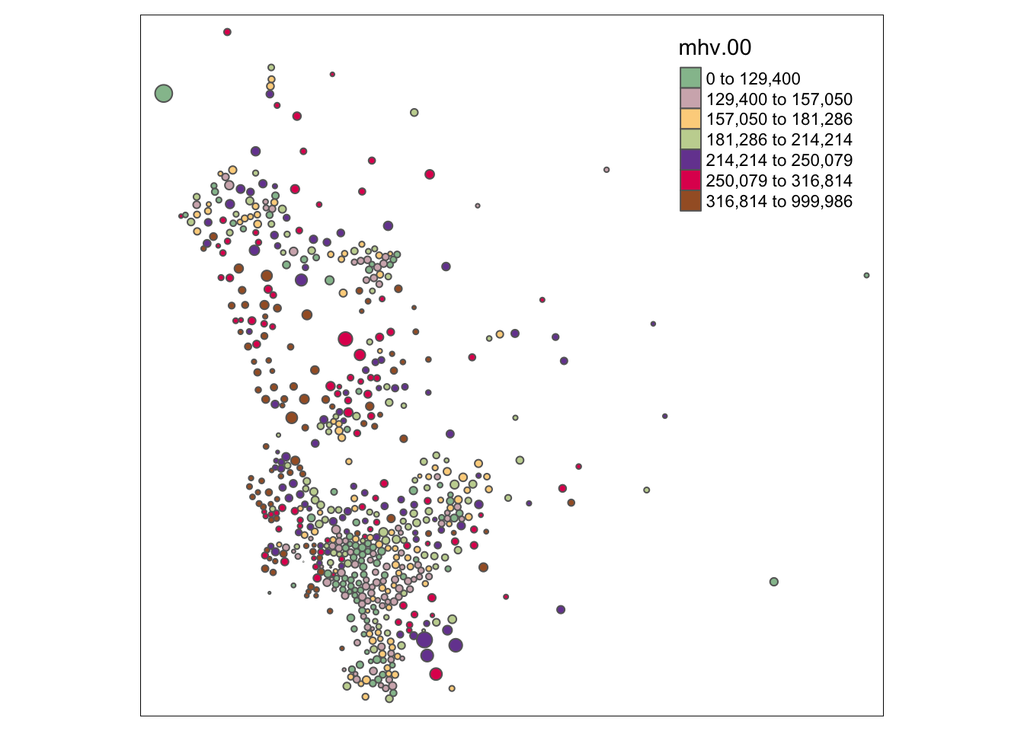

```r
tm_shape( san_dorling ) +
  tm_polygons( size="POP", col="mhv.00", n=7, style="quantile", palette="Accent" )
```

MHV Change

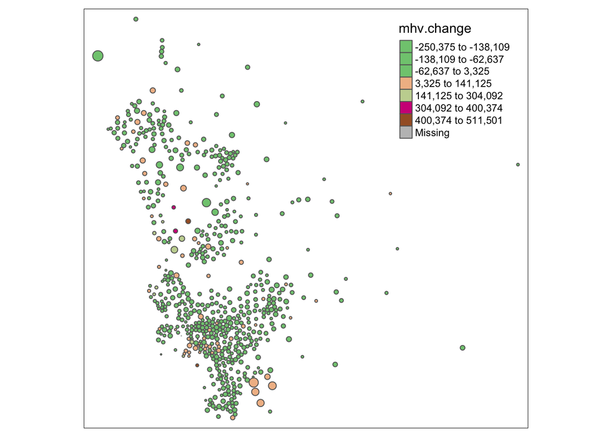

```r
tm_shape( san_dorling ) +
  tm_polygons( size="POP", col="mhv.change", n=7, style="hclust", palette="Accent" )
```

Gentrified

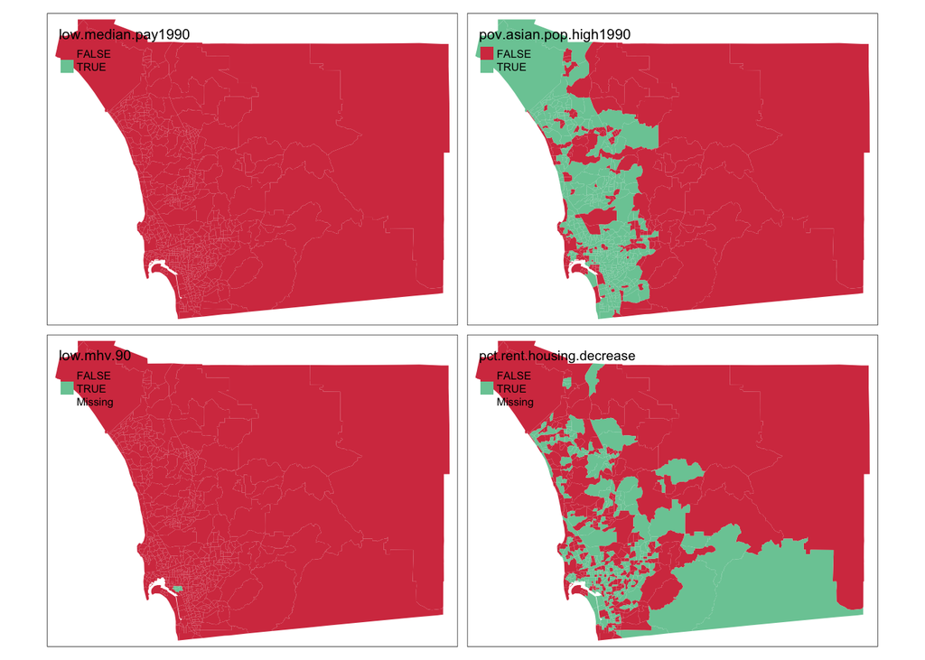

```r
tm_shape( san.sp ) +
  tm_fill( col= c("low.median.pay1990" , "pov.asian.pop.high1990" , "low.mhv.90" , "pct.rent.housing.decrease") , palette="Spectral" , geometry = TRUE)+
  tm_style("col_blind")
```

Describe the distribution of home values in 1990 - where are high and low-value tracts located in the city/cities?

1-low tracts are centered in the southern part of the city while we can see the higher home values are more dispersed in the outer edges of the city.

Compare values in 2000 to changes in values from 1990-2000. Do the largest gains occur in tracts with above or below-average home prices in 2000?

2-According to the map the largest gain occur in tracts above average home prices in 2000 so the high value homes are getting way more valuable compared to the medium and low value homes

Do you find any meaningful patterns in where gentrification occurs? low to high home values